# Clustering Effects on Epidemic Dynamics

NodeBasedModels.jl Vignette 08 (clustering effects)

Author

Simon Frost

Published

May 16, 2026

## Introduction

Triangles in a contact network — three mutual contacts $A$–$B$–$C$ all linked — slow down epidemics because once two of the three are infected, the third has fewer naive susceptible neighbours to spread to. The pair-approximation framework captures this through the **clustering coefficient** $\phi$ and a triangle-aware closure (Keeling, Barnard, or Eames).

This vignette quantifies the effect by sweeping $\phi$ from $0$ to $0.6$.

## Setup

```julia
using NodeBasedModels
using Plots
```

## Sweep

```julia
# Universal anchors: γ=0.25, R₀=2, β derived per scenario (see plan.md)
γ_anchor = 0.25
R0_target = 2.0
n_degree = 6
T_anchor = R0_target / (n_degree - 1)   # T = R₀/(k-1) = 0.4
τ_anchor = T_anchor * γ_anchor / (1 - T_anchor)  # 1/6

function final_size(ϕ; closure = KeelingClosure(), τ = τ_anchor, γ = γ_anchor)
    net = regular_network(n_degree; ϕ = ϕ)
    psys = generate_pairwise(sir_model(), net, closure;
                             tspan = (0.0, 40.0), N = 1.0,
                             seed_fraction = 0.01)
    p = copy(psys.params); p[:τ] = τ; p[:γ] = γ
    sol  = solve_pairwise(psys, p; reltol = 1e-8, abstol = 1e-10)
    return sol[psys.singles[:R]][end]
end

ϕgrid = 0.0:0.05:0.6
R∞_keeling = [final_size(ϕ; closure = KeelingClosure()) for ϕ in ϕgrid]
R∞_barnard = [final_size(ϕ; closure = BarnardClosure()) for ϕ in ϕgrid]
nothing
```

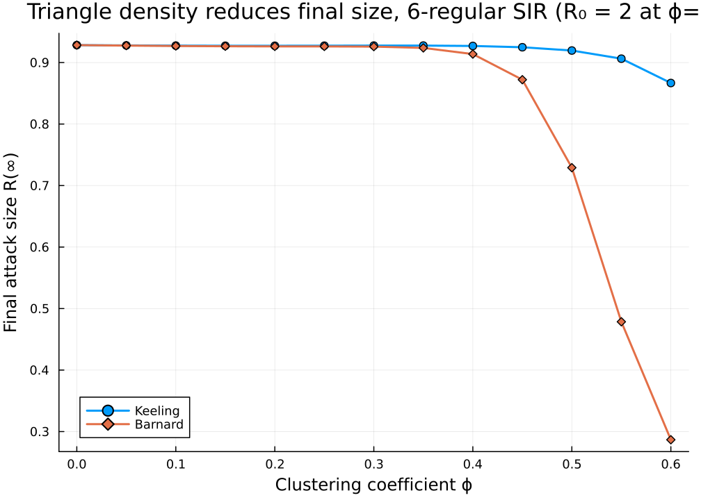

```julia
plot(ϕgrid, R∞_keeling, label = "Keeling", lw = 2, marker = :circle)
plot!(ϕgrid, R∞_barnard, label = "Barnard", lw = 2, marker = :diamond)
xlabel!("Clustering coefficient ϕ")
ylabel!("Final attack size R(∞)")
title!("Triangle density reduces final size, 6-regular SIR (R₀ = 2 at ϕ=0)")
```

As clustering grows, both Keeling and Barnard predict a smaller epidemic. The Bernoulli closure (no clustering correction) would predict the same final size at every $\phi$ — see vignette 02 for the comparison at a single $\phi$.

## Closures diverge as $\phi$ grows

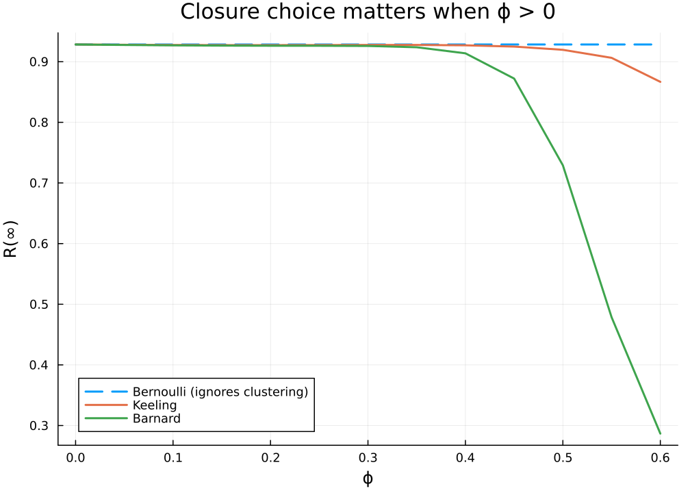

```julia
R∞_bernoulli = [final_size(ϕ; closure = BernoulliClosure()) for ϕ in ϕgrid]
plot(ϕgrid, R∞_bernoulli, label = "Bernoulli (ignores clustering)",
     lw = 2, ls = :dash)
plot!(ϕgrid, R∞_keeling, label = "Keeling", lw = 2)
plot!(ϕgrid, R∞_barnard, label = "Barnard", lw = 2)
xlabel!("ϕ"); ylabel!("R(∞)")
title!("Closure choice matters when ϕ > 0")
```